# GP_Evaluation1

Yuanxi Cheng

2022-09-09

### Evaluation of Boys, Girls, and Total Player Population

#### Player Population in Each State

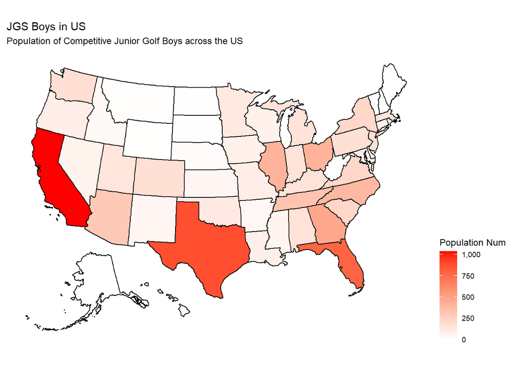

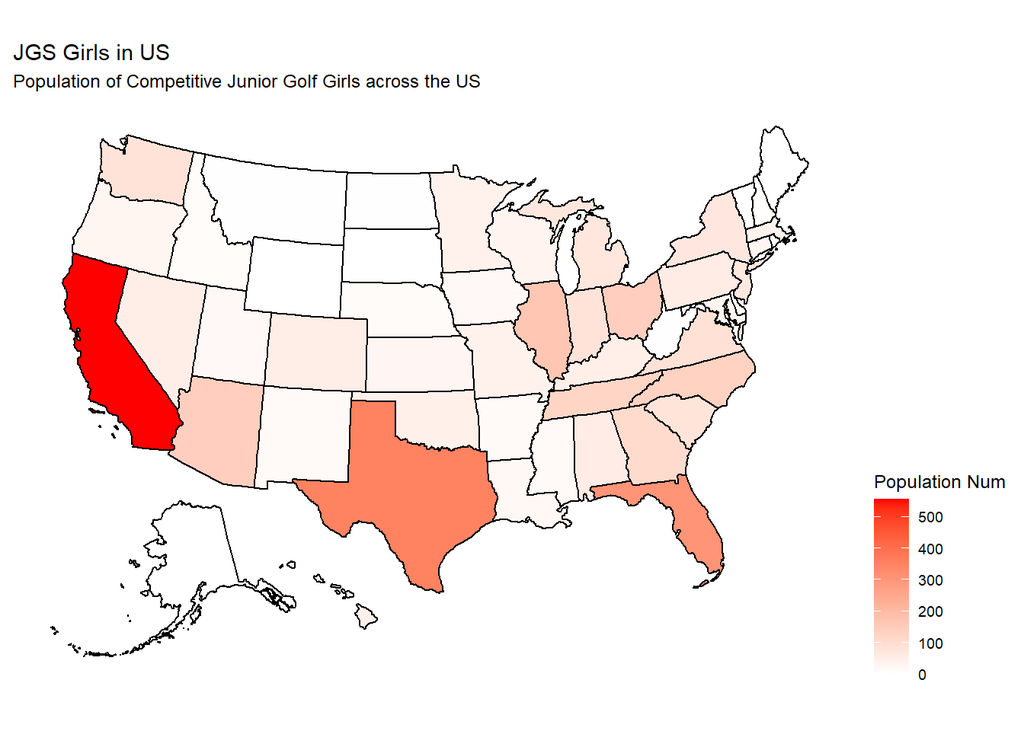

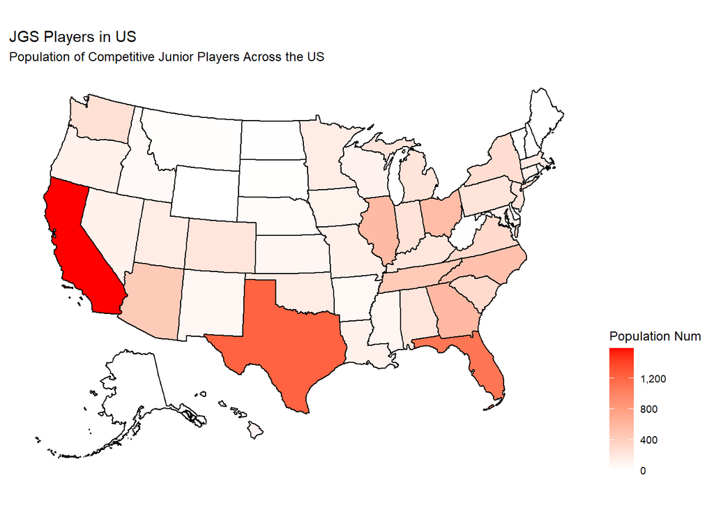

##### The three graphs above are plotted simply on how many of each population is recorded in each state based on the data we have. Looking at the results, we can visually see from these three maps that they display a similar pattern of density distribution within the states of California, Texas, and Florida. This makes sense, because golf is known to be a popular sport in those states, and the overall population of people within these states are greater than most of the other states. Something else that’s interesting to see how the popularity of golf mainly resides on the west and east regions of the US, leaving the middle rather unpopulated.

#### Standardized Player Population

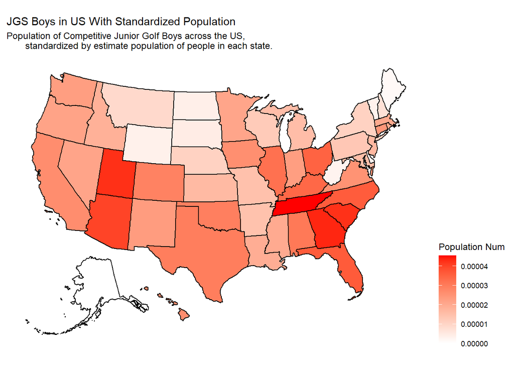

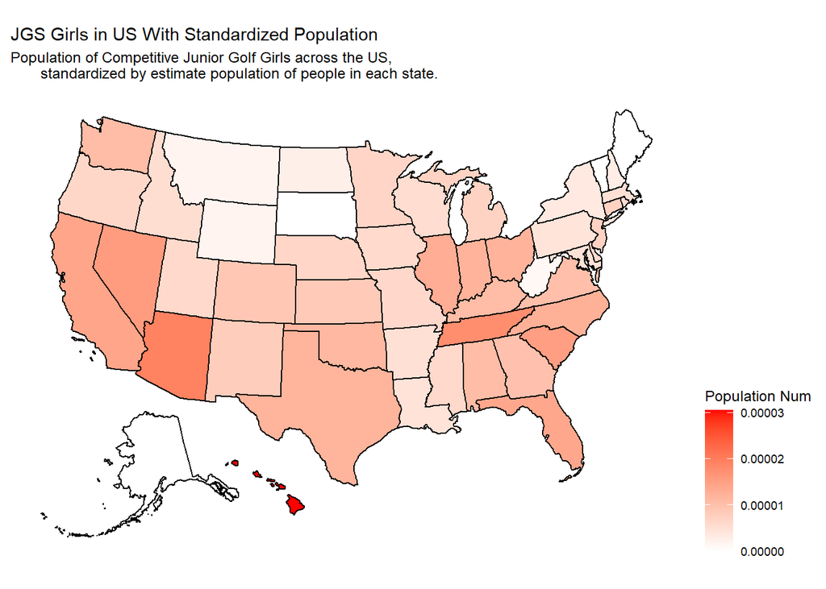

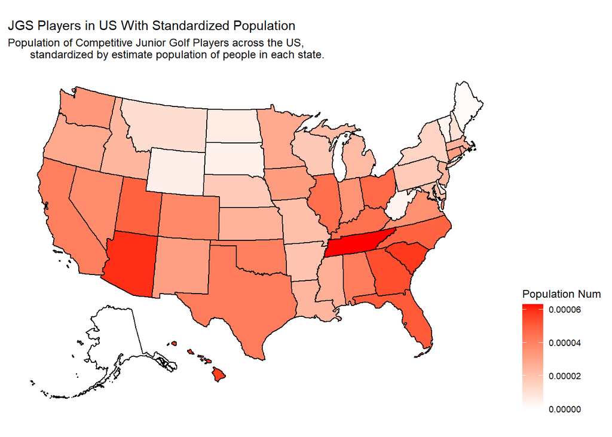

##### Standardizing the Population of players has a significant impact on the distribution and density of players within each state. When we standardize the population, what is meant is that the number of players in each state is divided by the total population of people within that state, therefore accounting for the different population sizes of each state. For example, for JGS Boys, the population of players in California is definitely larger than the population of players in Tennessee, but when taking into account for total state population, we realize that the number of players to the available population pool within Tennessee is actually higher than California’s. In a way, these graphs give a more accurate representation of the distribution of junior players within the states.

##### When observing and comparing these three graphs, we can see that girls have a more even distribution of the popularity of golf across the US, while the popularity of golf for junior boys seem to be more concentrated in Utah, Arizona, Tennessee, and Georgia. The middle region of the US does not seem as isolated of popularity in junior golf, either, but it appears that Wyoming just does not vibe with golf.

### Scatter Plots

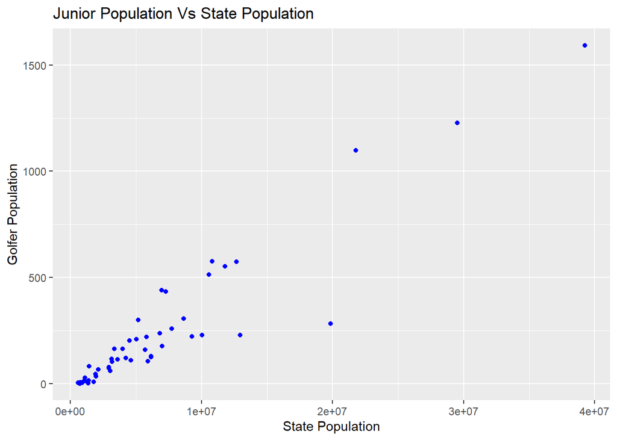

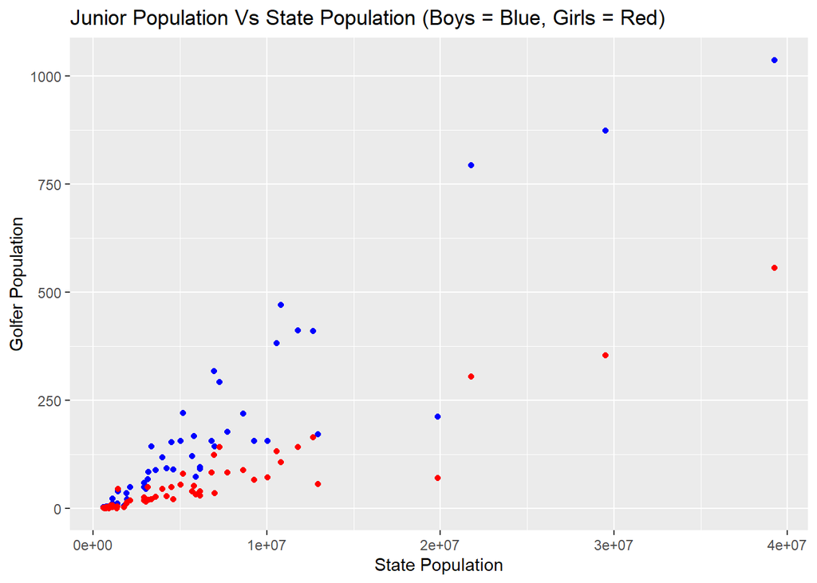

### Fitting Linear Models (Not Standardized Population)

### Boys:

#### Linear Regression Line

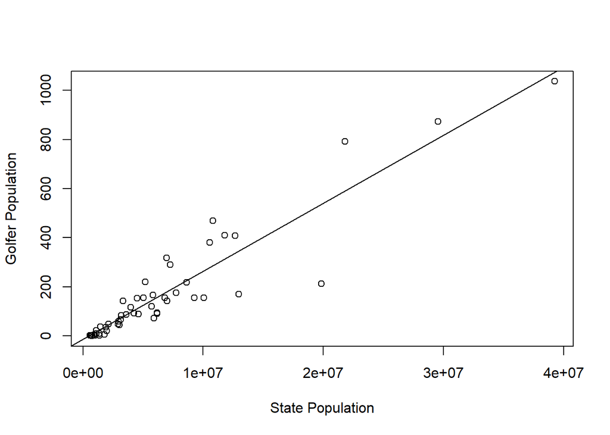

#### Analyzing Residuals and Testing Regression:

```
##
## Call:
## lm(formula = y ~ x, data = boysVsStatePop)
##
## Residuals:
##     Min      1Q  Median      3Q     Max
## -324.08  -24.38   -6.26   20.46  202.96
##
## Coefficients:
##               Estimate Std. Error t value Pr(>|t|)
## (Intercept) -1.422e+01  1.574e+01  -0.903    0.371
## x            2.774e-05  1.591e-06  17.436   <2e-16 ***
## ---
## Signif. codes:  0 '***' 0.001 '**' 0.01 '*' 0.05 '.' 0.1 ' ' 1
##
## Residual standard error: 82.7 on 48 degrees of freedom
## Multiple R-squared:  0.8636, Adjusted R-squared:  0.8608
## F-statistic:   304 on 1 and 48 DF,  p-value: < 2.2e-16
```

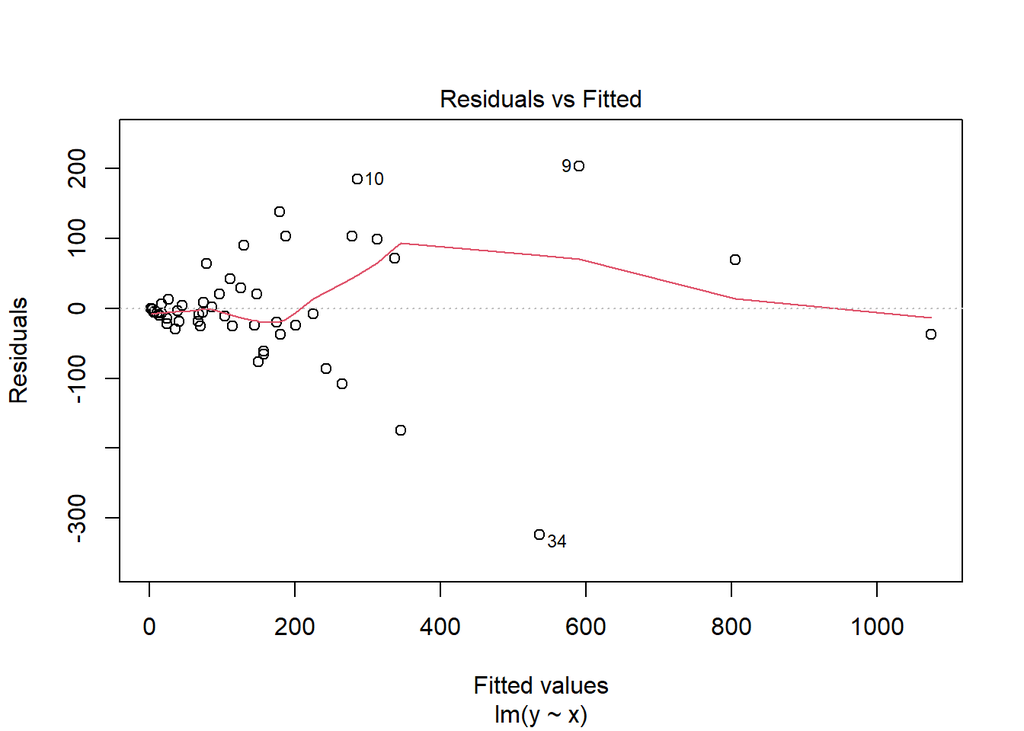

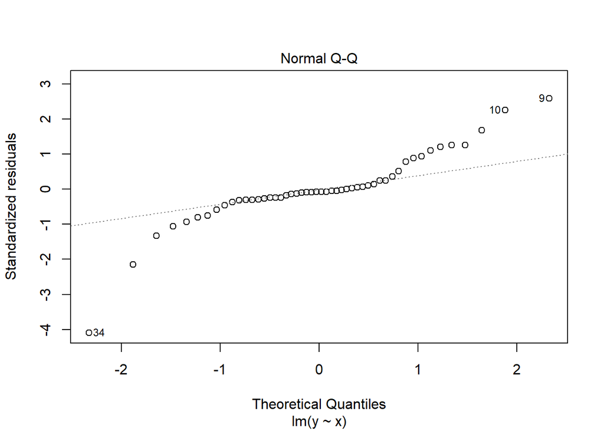

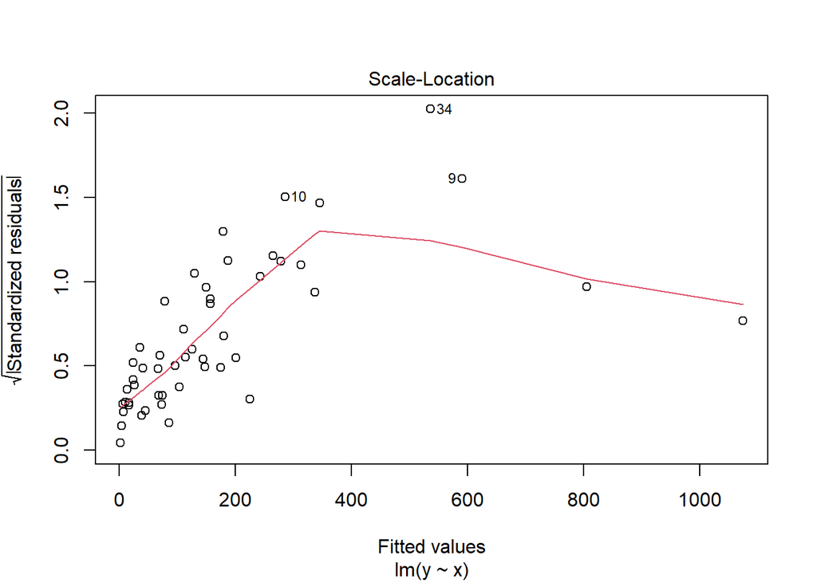

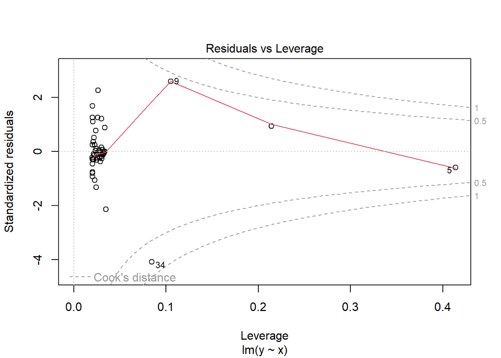

### Girls:

#### Linear Regression Line

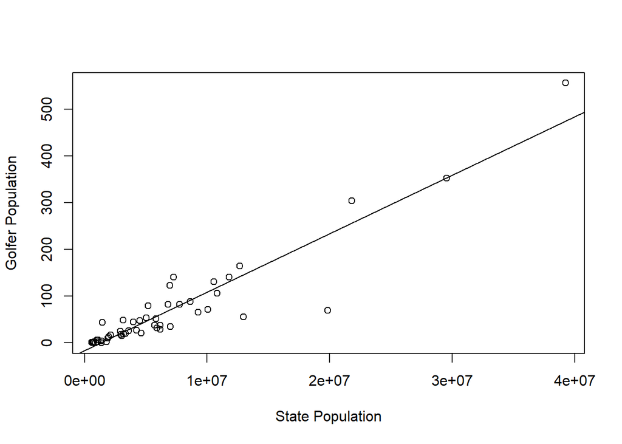

#### Analyzing Residuals and Testing Regression Girls:

```
##
## Call:
## lm(formula = y ~ x, data = girlsVsStatePop)
##
## Residuals:
##      Min       1Q   Median       3Q      Max
## -162.626   -5.868    4.138   10.230   81.435
##
## Coefficients:
##               Estimate Std. Error t value Pr(>|t|)
## (Intercept) -1.675e+01  6.900e+00  -2.427    0.019 *
## x            1.252e-05  6.973e-07  17.956   <2e-16 ***
## ---
## Signif. codes:  0 '***' 0.001 '**' 0.01 '*' 0.05 '.' 0.1 ' ' 1
##
## Residual standard error: 36.25 on 48 degrees of freedom
## Multiple R-squared:  0.8704, Adjusted R-squared:  0.8677
## F-statistic: 322.4 on 1 and 48 DF,  p-value: < 2.2e-16
```

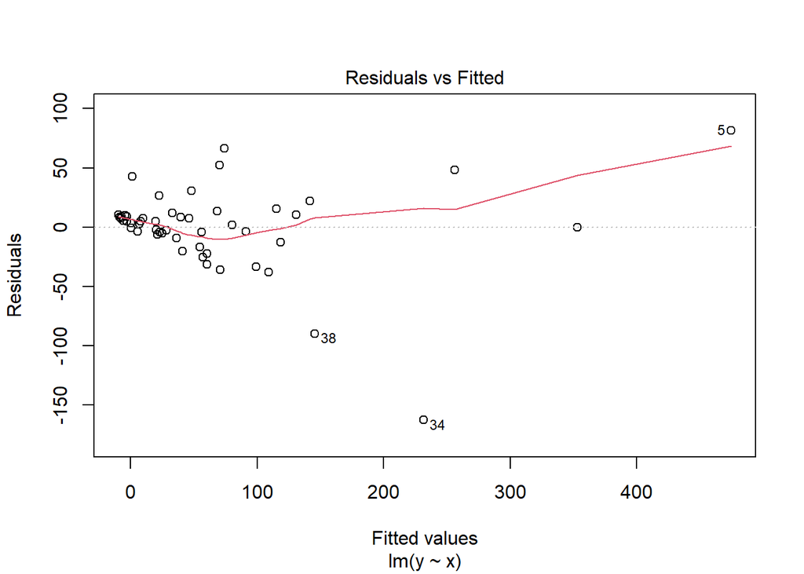

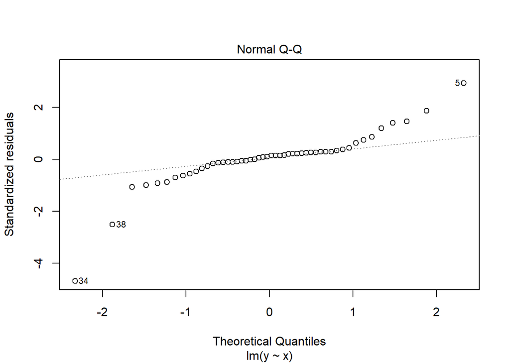

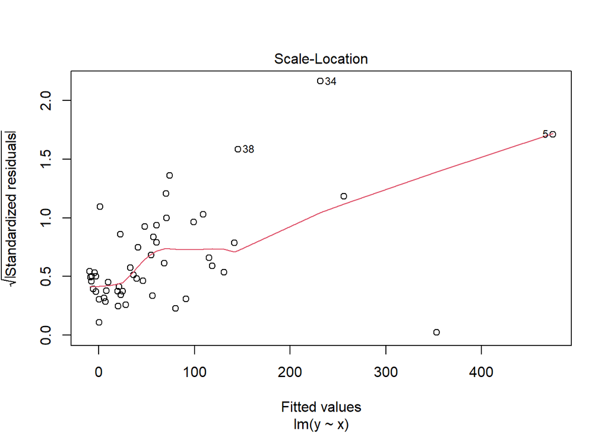

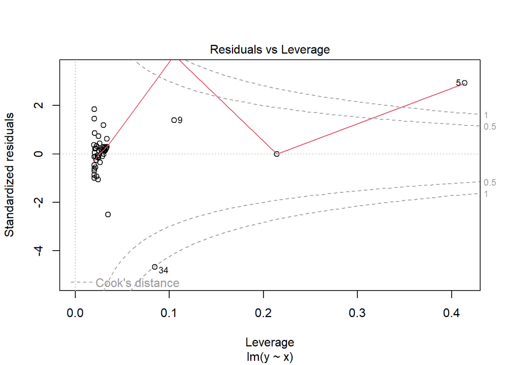

### Linear Modeling Summary

##### The lm() function in R creates a regression model with the given data, and the summary functions reviews the weights and performance measures of the model. The residuals allows us to measure and analyze the difference between prediction and actual results of the linear model. Residuals, along with other factors such as the p-value, are observed and tested to see how well the single-variable linear regression model fits the data.

##### Overall, we can confirm that state population is a significant predictor in the popularity of golf. Based on the model and graphs, the larger the state population, the more junior golf players are in that state.